# Lab 8

Author

Mel Balcarcel Arias

# Libraries

```r
library(tidyverse)
library(tidymodels)
library(powerjoin)
library(glue)
library(vip)
library(baguette)
library(dials)
library(glmnet)
library(patchwork)
library(ggplot2)
```

# Data Import/Tidy/Transform

## Reading in data

```r
root  <- 'https://gdex.ucar.edu/dataset/camels/file'
```

```r
download.file('https://gdex.ucar.edu/dataset/camels/file/camels_attributes_v2.0.pdf',
              'data/camels_attributes_v2.0.pdf')
```

```r
types <- c("clim", "geol", "soil", "topo", "vege", "hydro")
remote_files  <- glue('{root}/camels_{types}.txt')
local_files   <- glue('data/camels_{types}.txt')
walk2(remote_files, local_files, download.file, quiet = TRUE)
camels <- map(local_files, read_delim, show_col_types = FALSE)
camels <- power_full_join(camels ,by = 'gauge_id')
camels <- map(remote_files, read_delim, show_col_types = FALSE) |>
  power_full_join(by = 'gauge_id')
```

## Cleaning data

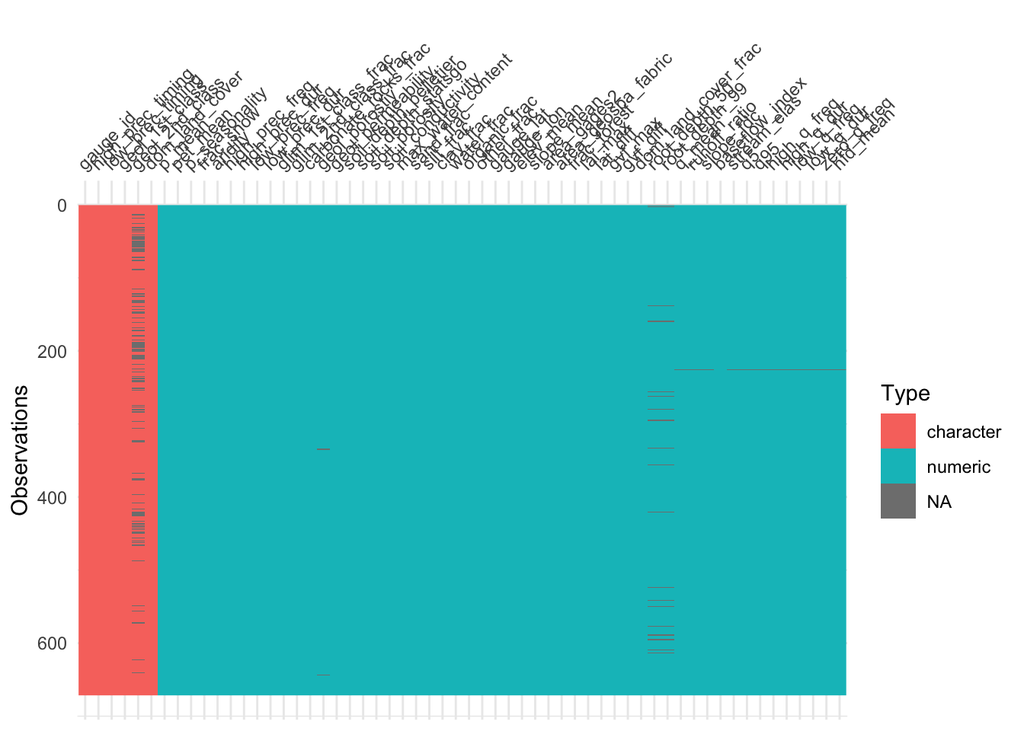

```r
visdat::vis_dat(camels)
```

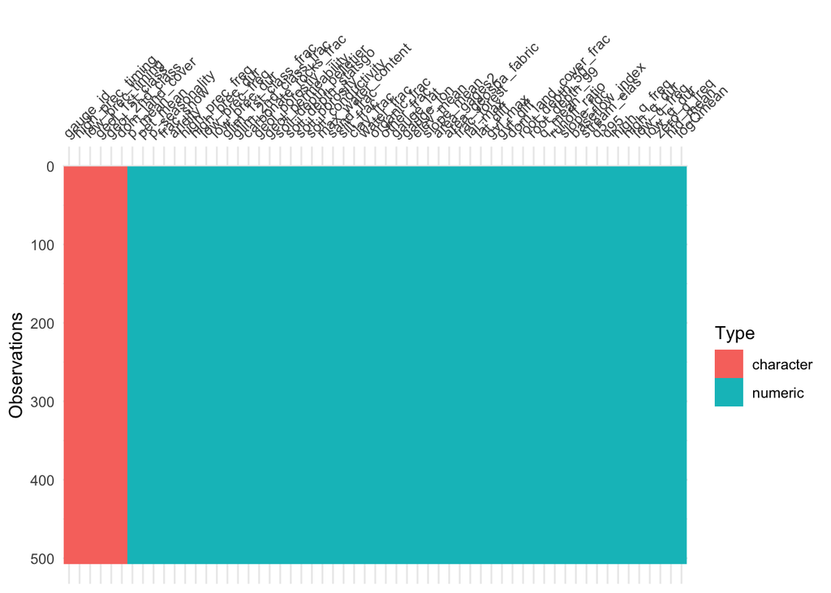

```r
cleaned_camels <- camels %>%
  drop_na()

cleaned_camels <- cleaned_camels %>%
  mutate(logQmean = log(q_mean))

visdat::vis_dat(cleaned_camels)
```

# Data Splitting

## Set seed, initial split, training/testing

```r
set.seed(666)

CC_split <- initial_split(cleaned_camels, prop = .80)
CC_train <- training(CC_split)
CC_test <- testing(CC_split)
```

# Feature Engineering

## Recipe determination

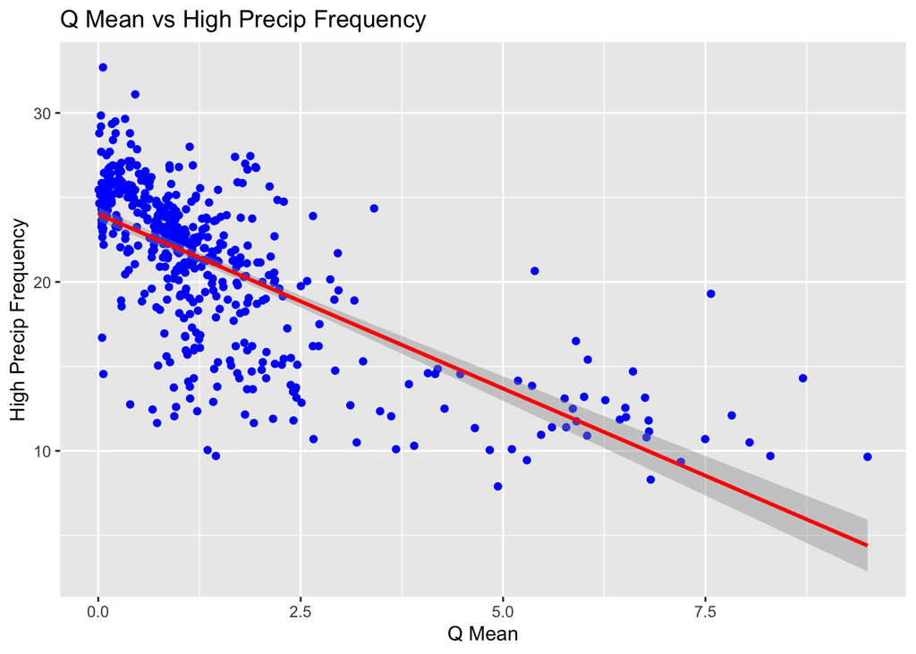

```r
ggplot(cleaned_camels, aes(x = q_mean, y = high_prec_freq)) +
  geom_point(color = "blue") +
  geom_smooth(method = "lm", color = "red") +
  labs(title = "Q Mean vs High Precip Frequency",
       x = "Q Mean",
       y = "High Precip Frequency")
```

```r
cor(cleaned_camels$q_mean, cleaned_camels$high_prec_freq, method = "pearson")
```

```
[1] -0.6935412
```

```r
cor.test(cleaned_camels$q_mean, cleaned_camels$high_prec_freq)
```

```
    Pearson's product-moment correlation

data:  cleaned_camels$q_mean and cleaned_camels$high_prec_freq
t = -21.634, df = 505, p-value < 2.2e-16
alternative hypothesis: true correlation is not equal to 0
95 percent confidence interval:
 -0.7361629 -0.6454402
sample estimates:
       cor
-0.6935412
```

## Makin a recipe

```r
CC_recipe <- recipe(q_mean ~ high_prec_freq + p_mean, data = CC_train) %>%
  step_impute_mean(all_predictors()) %>%
  step_normalize(all_predictors()) %>%
  step_zv(all_predictors())
```

# Resampling and Model Testing

## 1. Build Samples

```r
CC_folds <- vfold_cv(CC_train, v = 10)
```

## 2. Build 3 Candidate Models

```r
linear_model <-
  linear_reg() %>%
  set_engine("lm") %>%
  set_mode("regression")
```

```r
rf_model <-
  rand_forest(mtry = 1, trees = 500, min_n = 5) %>%
  set_engine("ranger") %>%
  set_mode("regression")
```

```r
boost_model <-
  boost_tree(trees = 500,
             learn_rate = 0.1,
             tree_depth = 6,
             loss_reduction = 0.01) %>%
  set_engine("xgboost") %>%
  set_mode("regression")
```

## 3. Test the Models

```r
models <- list(linear_model, rf_model, boost_model)
workflow_set <- workflow_set(
  preproc = list(CC_recipe),
  models = models
)
```

```r
results <- workflow_map(
  workflow_set,
  resamples = CC_folds,
  metrics = metric_set(rmse, rsq),
  verbose = TRUE
)
```

```
i   No tuning parameters. `fit_resamples()` will be attempted
```

```
i 1 of 3 resampling: recipe_linear_reg
```

```
✔ 1 of 3 resampling: recipe_linear_reg (262ms)
```

```
i   No tuning parameters. `fit_resamples()` will be attempted
```

```
i 2 of 3 resampling: recipe_rand_forest
```

```
✔ 2 of 3 resampling: recipe_rand_forest (916ms)
```

```
i   No tuning parameters. `fit_resamples()` will be attempted
```

```
i 3 of 3 resampling: recipe_boost_tree
```

```
✔ 3 of 3 resampling: recipe_boost_tree (994ms)
```

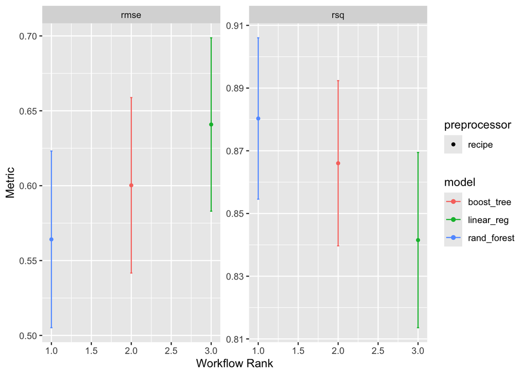

```r
autoplot(results)
```

## 4. Model Selection

The random forest performed the best in both metrics and it makes sense because in class, it seemed like a really powerful and useful model. The fact that it can make many small decision trees instead of focusing on one, likely means that it can come to many useful conclusions.

# Model Tuning

## 1. Build a model for your chosen specification

```r
tunable_rf_model <-
  rand_forest(
    mtry = tune(),
    min_n = tune(),
    trees = 1000
  ) %>%
  set_engine("ranger") %>%
  set_mode("regression")
```

## 2. Create a workflow

```r
rf_workflow <- workflow() %>%
  add_model(tunable_rf_model) %>%
  add_recipe(CC_recipe)
```

## 3. Check the tunable values/ranges

```r
dials_rf <- extract_parameter_set_dials(rf_workflow)
dials_rf$object
```

```
# Randomly Selected Predictors (quantitative)
```

```
Range: [1, ?]
```

```
Minimal Node Size (quantitative)
```

```
Range: [2, 40]
```

## 4. Define the search space

```r
dials_rf <- finalize(dials_rf, CC_train)

my.grid <- grid_latin_hypercube(
  dials_rf,
  size = 25
)
```

## 5. Tune the model

```r
model_params <-  tune_grid(
    rf_workflow,
    resamples = CC_folds,
    grid = my.grid,
    metrics = metric_set(rmse, rsq, mae),
    control = control_grid(save_pred = TRUE)
  )
```

```
→ A | warning: ! 56 columns were requested but there were 2 predictors in the data.
               ℹ 2 predictors will be used.
```

```
There were issues with some computations   A: x1
```

```
→ B | warning: ! 37 columns were requested but there were 2 predictors in the data.
               ℹ 2 predictors will be used.
```

[output not shown]

[output cut: 26 more lines]

[output not shown]

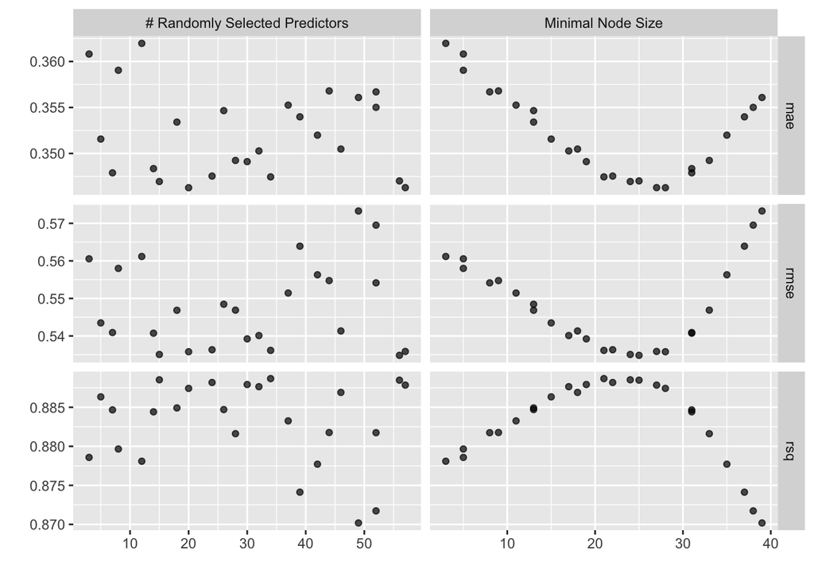

```r
autoplot(model_params)
```

Because we want low mae and rmse, the # of randomly selected predictors tells us that most values between 0 and 60 work relatively well with the exception of about 35 in mae and 50 in rmse. We want the inverse for rsq in randomly selected predictors and it looks like some values after 30 are not ideal. Looking at minimal node size, between 24 and 25 seems to be the best for mae, rmse, and rsq.

## 6. Check the skill of the tuned model

```r
metrics_rf <- collect_metrics(model_params)
best_mae_metrics <- metrics_rf %>%
  filter(.metric == "mae") %>%
  arrange(mean)
top_mae_results <- best_mae_metrics %>%
  slice_head(n = 5)
print(top_mae_results)
```

```
# A tibble: 5 × 8
   mtry min_n .metric .estimator  mean     n std_err .config
  <int> <int> <chr>   <chr>      <dbl> <int>   <dbl> <chr>
1    20    28 mae     standard   0.346    10  0.0157 Preprocessor1_Model13
2    57    27 mae     standard   0.346    10  0.0156 Preprocessor1_Model20
3    15    24 mae     standard   0.347    10  0.0155 Preprocessor1_Model16
4    56    25 mae     standard   0.347    10  0.0155 Preprocessor1_Model01
5    34    21 mae     standard   0.347    10  0.0159 Preprocessor1_Model09
```

```r
best_model_mae <- show_best(model_params, metric = "mae", n = 1)
print(best_model_mae)
```

```
# A tibble: 1 × 8
   mtry min_n .metric .estimator  mean     n std_err .config
  <int> <int> <chr>   <chr>      <dbl> <int>   <dbl> <chr>
1    20    28 mae     standard   0.346    10  0.0157 Preprocessor1_Model13
```

```r
hp_best <- select_best(model_params, metric = "mae")
```

## 7. Finalize your model

```r
final_rf_workflow <- finalize_workflow(rf_workflow, hp_best)
```

# Final Model verification

```r
final_fit <- last_fit(final_rf_workflow, CC_split)
```

```
→ A | warning: ! 20 columns were requested but there were 2 predictors in the data.
               ℹ 2 predictors will be used.
```

```r
final_metrics <- collect_metrics(final_fit)
print(final_metrics)
```

```
# A tibble: 2 × 4
  .metric .estimator .estimate .config
  <chr>   <chr>          <dbl> <chr>
1 rmse    standard       0.518 Preprocessor1_Model1
2 rsq     standard       0.905 Preprocessor1_Model1
```

Given that the range for q_mean is 0.004553165-9.503108088 our rmse of 0.52 is really good because it’s relatively small compared to our range. An rsq of 90% is also really good because it means that 90% of the variance can be explained.

```r
final_predictions <- collect_predictions(final_fit)
head(final_predictions)
```

```
# A tibble: 6 × 5
  .pred id                .row q_mean .config
  <dbl> <chr>            <int>  <dbl> <chr>
1  2.05 train/test split    12  2.38  Preprocessor1_Model1
2  1.47 train/test split    14  1.72  Preprocessor1_Model1
3  1.81 train/test split    23  1.53  Preprocessor1_Model1
4  1.81 train/test split    29  1.80  Preprocessor1_Model1
5  1.05 train/test split    49  1.12  Preprocessor1_Model1
6  1.03 train/test split    69  0.981 Preprocessor1_Model1
```

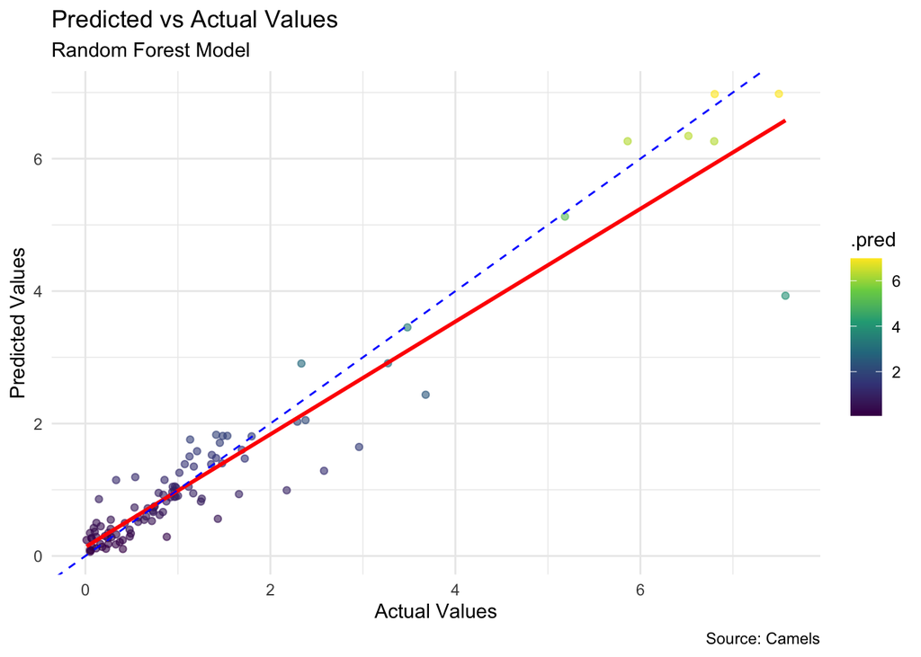

```r
library(ggplot2)

ggplot(final_predictions, aes(x = q_mean, y = .pred)) +
  geom_point(aes(color = .pred), alpha = 0.6) +
  geom_smooth(method = "lm", se = FALSE, color = "red") +
  geom_abline(slope = 1, intercept = 0, linetype = "dashed", color = "blue") +
  scale_color_viridis_c() +
  labs(
    x = "Actual Values",
    y = "Predicted Values",
    title = "Predicted vs Actual Values",
    subtitle = "Random Forest Model",
    caption = "Source: Camels"
  ) +
  theme_minimal()
```

# Buidling a map

```r
final_fit <- fit(final_rf_workflow, data = cleaned_camels)
```

```r
prediction_df <- augment(final_fit, new_data = cleaned_camels) %>%
  mutate(
    residual = (q_mean - .pred)^2
  )
```

```r
pred_map <- ggplot(data = prediction_df, aes(x = gauge_lon, y = gauge_lat)) +
  borders("state", colour = "gray50") +
  geom_point(aes(color = .pred)) +
  scale_color_gradient(low = "pink", high = "dodgerblue", name = "Prediction") +
  ggthemes::theme_map() +
  labs(title = "Predicted q_mean across CONUS")
```

```r
resid_map <- ggplot(data = prediction_df, aes(x = gauge_lon, y = gauge_lat)) +
  borders("state", colour = "gray50") +
  geom_point(aes(color = residual)) +
  scale_color_gradient(low = "pink", high = "dodgerblue", name = "Residuals") +
  ggthemes::theme_map() +
  labs(title = "Prediction Residuals across CONUS")
```

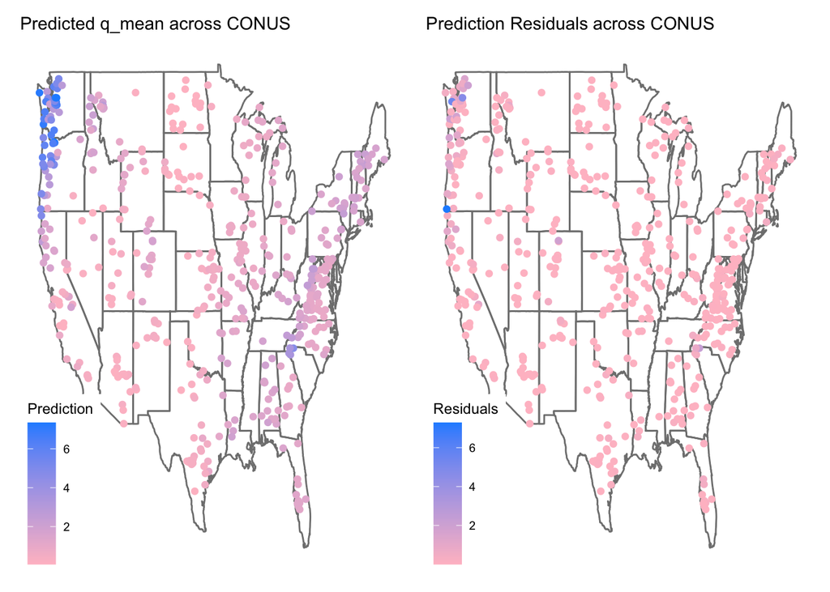

```r
combined_map <- pred_map + resid_map
combined_map
```